# Notebook

## Section 11 — NaN/Inf Cleaning & Model Training

### Model

GBT Regressor with fixed hyperparameters, operating on a `Pipeline` of: `StringIndexer(GRADE → GRADE_idx)` → `VectorAssembler` → `GBTRegressor`

```python
def compute_metrics(pred_df, label_col, pred_col):
    """Compute RMSE, MAE, R² using Spark evaluators."""
    evs = {
        "RMSE": RegressionEvaluator(labelCol=label_col, predictionCol=pred_col, metricName="rmse"),
        "MAE":  RegressionEvaluator(labelCol=label_col, predictionCol=pred_col, metricName="mae"),
        "R2":   RegressionEvaluator(labelCol=label_col, predictionCol=pred_col, metricName="r2"),
    }
    return {name: ev.evaluate(pred_df) for name, ev in evs.items()}


# ── BUG MT-2 FIX: type-aware NaN / Inf check ────────────────────────────
float_type_cols = {
    f.name for f in train_df.schema.fields
    if str(f.dataType) in ("DoubleType()", "FloatType()")
}

print("Checking training data for NaN / Inf in feature columns...")
for c in FEATURE_COLS:
    if c in float_type_cols:
        bad_cnt = train_df.filter(
            F.col(c).isNull() | F.isnan(c) |
            (F.col(c) == float("inf")) | (F.col(c) == float("-inf"))
        ).count()
    else:
        bad_cnt = train_df.filter(F.col(c).isNull()).count()
    if bad_cnt > 0:
        print(f"  {c}: {bad_cnt} problematic rows — will be dropped")

def clean_df(sdf, float_cols, all_feature_cols):
    """Drop rows with NaN/Inf (floats) or NULL (ints) in any feature column."""
    out = sdf
    for c in all_feature_cols:
        if c in float_cols:
            out = out.filter(
                ~F.isnan(c) &
                (F.col(c) != float("inf")) &
                (F.col(c) != float("-inf")) &
                F.col(c).isNotNull()
            )
        else:
            out = out.filter(F.col(c).isNotNull())
    return out

train_df_clean = clean_df(train_df, float_type_cols, FEATURE_COLS)
# BUG MT-3 FIX: clean val_df too — was missing in original code
val_df_clean   = clean_df(val_df,   float_type_cols, FEATURE_COLS)

print(f"Train rows before cleaning : {train_df.count():,}")
print(f"Train rows after  cleaning : {train_df_clean.count():,}")
print(f"Val   rows after  cleaning : {val_df_clean.count():,}")

# ── Build pipeline ───────────────────────────────────────────────────────
grade_indexer = StringIndexer(inputCol="GRADE", outputCol="GRADE_idx", handleInvalid="keep")
all_feature_cols = FEATURE_COLS + ["GRADE_idx"]
assembler = VectorAssembler(inputCols=all_feature_cols, outputCol="features", handleInvalid="keep")

gbt = GBTRegressor(
    labelCol=LABEL_COL, featuresCol="features", weightCol=WEIGHT_COL,
    seed=42, maxBins=256,
    maxDepth=BEST_MAX_DEPTH, maxIter=BEST_MAX_ITER,
    stepSize=BEST_STEP_SIZE, subsamplingRate=BEST_SUBSAMPLING_RATE,
)

pipeline = Pipeline(stages=[grade_indexer, assembler, gbt])

print(f"\nTraining GBT (maxDepth={BEST_MAX_DEPTH}, maxIter={BEST_MAX_ITER}, "
      f"stepSize={BEST_STEP_SIZE}, subsampling={BEST_SUBSAMPLING_RATE}) ...")
model = pipeline.fit(train_df_clean)
print("Training complete.")

val_pred = model.transform(val_df_clean)
val_pred = (
    val_pred
    .withColumn("prediction", F.col("prediction").cast(DoubleType()))
    .withColumn(LABEL_COL,    F.col(LABEL_COL).cast(DoubleType()))
)

gbt_metrics = compute_metrics(val_pred, LABEL_COL, "prediction")
best_metrics = gbt_metrics

print(f"\n{'='*60}")
print(f"  GBT MODEL — Validation Metrics (SY {VAL_START_YEAR}–{VAL_END_YEAR})")
print(f"{'='*60}")
print(f"  RMSE : {gbt_metrics['RMSE']:.2f}")
print(f"  MAE  : {gbt_metrics['MAE']:.2f}")
print(f"{'='*60}")
```

```
StatementMeta(, b4c79e94-c416-4b78-8c76-627f086c7518, 16, Finished, Available, Finished, False)
```

```
Checking training data for NaN / Inf in feature columns...
Train rows before cleaning : 31,005
Train rows after  cleaning : 31,005
Val   rows after  cleaning : 5,529

Training GBT (maxDepth=5, maxIter=100, stepSize=0.1, subsampling=0.8) ...
```

```
Training complete.

============================================================
  GBT MODEL — Validation Metrics (SY 2026–2026)
============================================================
  RMSE : 43.10
  MAE  : 10.70
============================================================
```

```python
import matplotlib.pyplot as plt

# ── 16a. Attach / normalize NETWORK on the feature table ───────────────────
network_candidates = [c for c in dim.columns if "NETWORK" in c.upper()]
print(f"Candidate network columns in dim_school: {network_candidates}")
NETWORK_COL = network_candidates[0] if network_candidates else None

if "NETWORK" in df.columns:
    # NETWORK already present from feature engineering; just clean it up.
    df_net = df.withColumn(
        "NETWORK",
        F.coalesce(F.trim(F.col("NETWORK").cast("string")), F.lit("UNKNOWN"))
    )
    print("Using NETWORK column already present in feature table.")
elif NETWORK_COL is not None:
    # Fallback: join from dim_school if not already in df
    net_lookup = dim_dedup.select("SCHOOL_KEY", F.col(NETWORK_COL).alias("NETWORK"))
    df_net = df.join(net_lookup, on="SCHOOL_KEY", how="left")
    df_net = df_net.withColumn(
        "NETWORK",
        F.coalesce(F.trim(F.col("NETWORK").cast("string")), F.lit("UNKNOWN"))
    )
    print(f"Using NETWORK column from dim_school: '{NETWORK_COL}'")
else:
    # Last-resort fallback so the rest of the notebook still runs end-to-end.
    df_net = df.withColumn("NETWORK", F.coalesce(F.col("GOVERNANCE"), F.lit("UNKNOWN")))
    print("No NETWORK column found -> falling back to GOVERNANCE as 'NETWORK'.")

print(f"Distinct networks: {df_net.select('NETWORK').distinct().count()}")


# ── 16b. Per-fold helpers (mirror the notebook's train-only imputation) ───
def impute_train_only(train_sdf, test_sdf, cols):
    """Compute medians from TRAIN only; apply to both train and test (no leakage)."""
    fills = {}
    for c in cols:
        q = train_sdf.filter(F.col(c).isNotNull()).approxQuantile(c, [0.5], 0.01)
        fills[c] = q[0] if q else 0.0
    return train_sdf.fillna(fills), test_sdf.fillna(fills)


def add_weights(train_sdf, test_sdf):
    """Down-weight migrant-anomaly years (2022-24) in training; test weight = 1.0."""
    train_sdf = train_sdf.withColumn(
        WEIGHT_COL,
        F.when(F.col("IS_MIGRANT_ANOMALY_YEAR") == 1, F.lit(0.3)).otherwise(F.lit(1.0))
    )
    test_sdf = test_sdf.withColumn(WEIGHT_COL, F.lit(1.0))
    return train_sdf, test_sdf


def csr_prediction_col(sdf):
    """Faithful CSR baseline: FEEDER_GRADE_LAST_YEAR * AVG_SURVIVAL_RATE_3YR."""
    return sdf.withColumn(
        "y_hat_CSR",
        (F.col("FEEDER_GRADE_LAST_YEAR") *
         F.coalesce(F.col("AVG_SURVIVAL_RATE_3YR"), F.lit(1.0))).cast(DoubleType())
    )


# Evaluation years: need >= a few years of history before the first fold.
BACKTEST_START_YEAR = TRAIN_START_YEAR + 3          # 2023 by default
data_max_year = df_net.select(F.max(TIME_COL)).collect()[0][0]
EVAL_YEARS = list(range(BACKTEST_START_YEAR, int(data_max_year) + 1))

print(f"\nExpanding-window backtest")
print(f"  Train start (fixed) : {TRAIN_START_YEAR}")
print(f"  Evaluation years    : {EVAL_YEARS}")
```

```
StatementMeta(, b4c79e94-c416-4b78-8c76-627f086c7518, 17, Finished, Available, Finished, False)
```

```
Candidate network columns in dim_school: ['NETWORK', 'NETWORK_CHIEF', 'GEO_NETWORK', 'ES_NETWORK']
Using NETWORK column already present in feature table.
Distinct networks: 23

Expanding-window backtest
  Train start (fixed) : 2020
  Evaluation years    : [2023, 2024, 2025, 2026]
```

```python
# ── Train the XGBoost model for the entry grades K & 9 (K/9 rows only) ──────
import numpy as np, pandas as pd, xgboost as xgb

ENTRY_GRADES = ["K", "9"]
# Same 18 features (and order) as XGBoost_KG_Grade9_Training.ipynb
XGB_FEATURES = ["SAME_GRADE_LAST_YEAR","SAME_GRADE_2YR_AGO","FEEDER_GRADE_LAST_YEAR",
    "FEEDER_GRADE_2YR_AGO","HAS_FEEDER_GRADE","SCHOOL_TOTAL_LAST_YEAR","COHORT_SURVIVAL_RATE",
    "AVG_SURVIVAL_RATE_3YR","DISTRICT_GRADE_ENROLLMENT_LAST_YEAR","IS_MIGRANT_ANOMALY_YEAR",
    "GRADE_NUMERIC","SCHOOL_KEY","GOVERNANCE_ENCODED","IS_SELECTIVE","IS_ATTENDANCE_AREA",
    "IS_SMALL_SCHOOL","IS_HIGH_SCHOOL","REGION_ENCODED"]
XGB_PARAMS = dict(n_estimators=100, max_depth=5, learning_rate=0.1, subsample=0.8,
    colsample_bytree=0.8, objective="reg:squarederror", tree_method="hist",
    missing=np.nan, random_state=42, n_jobs=-1)

# Entry-grade rows -> pandas (nulls KEPT — never median-filled, unlike the GBT path)
ekeep = list(dict.fromkeys(XGB_FEATURES + [LABEL_COL, TIME_COL, "GRADE", "SCHOOL_KEY", "NETWORK"]))
entry_pdf = df_net.filter(F.col("GRADE").isin(ENTRY_GRADES)).select(*ekeep).toPandas()
for c in XGB_FEATURES + [LABEL_COL, TIME_COL]:
    entry_pdf[c] = pd.to_numeric(entry_pdf[c], errors="coerce")
entry_pdf["GRADE"] = entry_pdf["GRADE"].astype(str)

# Train on the SAME window as the GBT (TRAIN_START_YEAR..TRAIN_END_YEAR), K/9 only
etr = entry_pdf[(entry_pdf[TIME_COL] >= TRAIN_START_YEAR) & (entry_pdf[TIME_COL] <= TRAIN_END_YEAR)]
ew = np.where(etr["IS_MIGRANT_ANOMALY_YEAR"].fillna(0) == 1, 0.3, 1.0)  # same surge down-weighting
xgb_k9_model = xgb.XGBRegressor(**XGB_PARAMS)
xgb_k9_model.fit(etr[XGB_FEATURES], etr[LABEL_COL].astype(float), sample_weight=ew)
print(f"XGBoost (K & 9) trained on {len(etr):,} entry-grade rows, "
      f"years {TRAIN_START_YEAR}-{TRAIN_END_YEAR} (nulls kept).")
```

```
StatementMeta(, b4c79e94-c416-4b78-8c76-627f086c7518, 18, Finished, Available, Finished, False)
```

```
XGBoost (K & 9) trained on 4,057 entry-grade rows, years 2020-2025 (nulls kept).
```

# STAGE 3 — Validation: Combined-System Metrics

Score the held-out validation year with **both** models (GBT for continuing grades, XGBoost for K & 9), merge, and report combined MAE / RMSE / MAPE / MedAPE / R² vs CSR.

```python
# ── Validation on the held-out year(s): COMBINED system (GBT + XGBoost) vs CSR ──
from sklearn.metrics import mean_absolute_error, r2_score

# GBT on the continuing grades of the validation window
val_cont = val_df.filter(~F.col("GRADE").isin(ENTRY_GRADES)).fillna(median_fills)
gpred = model.transform(val_cont).select(
    "GRADE",
    F.col(LABEL_COL).cast("double").alias("y"),
    F.col("prediction").cast("double").alias("y_hat"),
    (F.col("FEEDER_GRADE_LAST_YEAR") * F.col("AVG_SURVIVAL_RATE_3YR")).cast("double").alias("y_hat_CSR"),
).toPandas()

# XGBoost on K & 9 of the validation window (nulls kept)
val_e = entry_pdf[(entry_pdf[TIME_COL] >= VAL_START_YEAR) & (entry_pdf[TIME_COL] <= VAL_END_YEAR)].copy()
val_e["y"] = val_e[LABEL_COL].astype(float)
val_e["y_hat"] = np.clip(xgb_k9_model.predict(val_e[XGB_FEATURES]), 0, None)
val_e["y_hat_CSR"] = val_e["FEEDER_GRADE_LAST_YEAR"] * val_e["AVG_SURVIVAL_RATE_3YR"].fillna(1.0)

val_comb = pd.concat([gpred[["GRADE","y","y_hat","y_hat_CSR"]],
                      val_e[["GRADE","y","y_hat","y_hat_CSR"]]], ignore_index=True)

def _metrics(y, yh):
    y = np.asarray(y, float); yh = np.asarray(yh, float); pos = y > 0
    return {"MAE": mean_absolute_error(y, yh), "RMSE": float(np.sqrt(np.mean((y-yh)**2))),
            "MAPE": float(np.mean(np.abs((y[pos]-yh[pos])/y[pos]))*100),
            "MedAPE": float(np.median(np.abs((y[pos]-yh[pos])/y[pos]))*100),
            "R2": r2_score(y, yh) if len(np.unique(y)) > 1 else np.nan}

yv = val_comb["y"].values
val_summary = pd.DataFrame({"CSR (old)": _metrics(yv, val_comb["y_hat_CSR"]),
                            "HYBRID (GBT + XGBoost)": _metrics(yv, val_comb["y_hat"])}).T[
    ["MAE","RMSE","MAPE","MedAPE","R2"]]
print("="*74)
print(f"VALIDATION (held-out SY{VAL_START_YEAR}-{VAL_END_YEAR}) — COMBINED SYSTEM vs CSR")
print("="*74)
print(val_summary.round(2).to_string())
```

```
StatementMeta(, b4c79e94-c416-4b78-8c76-627f086c7518, 19, Finished, Available, Finished, False)
```

```
==========================================================================
VALIDATION (held-out SY2026-2026) — COMBINED SYSTEM vs CSR
==========================================================================
                           MAE     RMSE    MAPE  MedAPE       R2
CSR (old)               249.83  4358.18  117.20   25.79 -1534.62
HYBRID (GBT + XGBoost)   10.76    37.40   46.94   16.71     0.89
```

## Section 12 — CSR Baseline Comparison

The correct formula is:

```
# ✅ Fixed — matches domain definition exactly
csr_prediction = FEEDER_GRADE_LAST_YEAR * AVG_SURVIVAL_RATE_3YR
```

where `AVG_SURVIVAL_RATE_3YR` is the leak-free 3-year average cross-grade ratio built in Section 4. This is exactly what the current SAS system does.

```python
# CSR baseline = FEEDER_GRADE_LAST_YEAR * AVG_SURVIVAL_RATE_3YR
# Both columns are leak-free (fully lagged) from Section 4 and 5.
# This matches the domain guide definition exactly.
val_pred_csr = (
    val_pred
    .withColumn(
        "csr_prediction",
        (
            F.col("FEEDER_GRADE_LAST_YEAR") *
            F.coalesce(F.col("AVG_SURVIVAL_RATE_3YR"), F.lit(1.0))
        ).cast(DoubleType())
    )
)

csr_metrics = compute_metrics(val_pred_csr, LABEL_COL, "csr_prediction")

print(f"\n{'='*60}")
print(f"  CSR BASELINE  (FEEDER_GRADE_LAST_YEAR × AVG_SURVIVAL_RATE_3YR)")
print(f"  [Domain guide definition: grade N-1 count × historical cross-grade ratio]")
print(f"{'='*60}")
print(f"  RMSE : {csr_metrics['RMSE']:.2f}")
print(f"  MAE  : {csr_metrics['MAE']:.2f}")

rmse_improvement = (csr_metrics['RMSE'] - gbt_metrics['RMSE']) / csr_metrics['RMSE'] * 100
print(f"\n  ML improvement over CSR baseline: {rmse_improvement:.1f}% RMSE reduction")
if rmse_improvement > 0:
    print("  ✔ ML model is BETTER than the CSR baseline.")
else:
    print("  ✘ ML model is NOT better than CSR yet — review features or hyperparameters.")
print(f"{'='*60}")
```

```
StatementMeta(, b4c79e94-c416-4b78-8c76-627f086c7518, 20, Finished, Available, Finished, False)
```

```
============================================================
  CSR BASELINE  (FEEDER_GRADE_LAST_YEAR × AVG_SURVIVAL_RATE_3YR)
  [Domain guide definition: grade N-1 count × historical cross-grade ratio]
============================================================
  RMSE : 4358.18
  MAE  : 249.83

  ML improvement over CSR baseline: 99.0% RMSE reduction
  ✔ ML model is BETTER than the CSR baseline.
============================================================
```

## Section 13 — Feature Importance

```python
gbt_model   = model.stages[-1]
importances = gbt_model.featureImportances.toArray()

fi_df = pd.DataFrame({
    "feature":    all_feature_cols,
    "importance": importances,
}).sort_values("importance", ascending=False).reset_index(drop=True)

print("Feature Importance:")
for _, row in fi_df.iterrows():
    bar = "█" * int(row["importance"] * 40)
    print(f"  {row['feature']:45s} {row['importance']:.4f}  {bar}")

v3_features = ["GOVERNANCE_ENCODED", "IS_SELECTIVE", "IS_ATTENDANCE_AREA",
               "IS_SMALL_SCHOOL", "IS_HIGH_SCHOOL", "REGION_ENCODED"]
v3_importance = fi_df[fi_df["feature"].isin(v3_features)]["importance"].sum()
print(f"\n  V3 school-type features combined importance: {v3_importance:.4f}")
print(f"  (> 0.05 indicates school type is meaningfully contributing)")
```

```
StatementMeta(, b4c79e94-c416-4b78-8c76-627f086c7518, 21, Finished, Available, Finished, False)
```

```
Feature Importance:
  SAME_GRADE_LAST_YEAR                          0.5825  ███████████████████████
  SCHOOL_TOTAL_LAST_YEAR                        0.0955  ███
  DISTRICT_GRADE_ENROLLMENT_LAST_YEAR           0.0541  ██
  FEEDER_GRADE_2YR_AGO                          0.0422  █
  GRADE_idx                                     0.0398  █
  SCHOOL_KEY                                    0.0394  █
  REGION_ENCODED                                0.0360  █
  COHORT_SURVIVAL_RATE                          0.0237
  FEEDER_GRADE_LAST_YEAR                        0.0223
  SAME_GRADE_2YR_AGO                            0.0189
  AVG_SURVIVAL_RATE_3YR                         0.0125
  IS_ATTENDANCE_AREA                            0.0088
  IS_HIGH_SCHOOL                                0.0086
  IS_SELECTIVE                                  0.0065
  HAS_FEEDER_GRADE                              0.0046
  IS_MIGRANT_ANOMALY_YEAR                       0.0025
  GRADE_NUMERIC                                 0.0018
  GOVERNANCE_ENCODED                            0.0002
  IS_SMALL_SCHOOL                               0.0001

  V3 school-type features combined importance: 0.0601
  (> 0.05 indicates school type is meaningfully contributing)
```

# STAGE 4 — Year-wise Backtest (walk-forward, combined system)

For each past year `T`: refit GBT on continuing grades and XGBoost on K & 9 using years `< T`, predict `T`, and merge. `preds_pdf.y_hat_ML` **is the hybrid system**, so every comparison below is the combined system vs CSR.

```python
# ── Walk-forward backtest of the COMBINED system (no grade overlap) ──────────
# Each fold: GBT refit on continuing grades, XGBoost refit on K & 9, both on years
# < T, predict T, then merge. preds_pdf.y_hat_ML = the HYBRID prediction, so every
# comparison/chart below reflects the combined system vs CSR.
import numpy as np, pandas as pd, xgboost as xgb
from pyspark.sql.types import DoubleType

is_entry_sql = F.col("GRADE").isin(ENTRY_GRADES)
# entry rows once (nulls kept), now carrying NETWORK for the network-wise view
ekeep2 = list(dict.fromkeys(XGB_FEATURES + [LABEL_COL, TIME_COL, "GRADE", "SCHOOL_KEY", "NETWORK"]))
entry_all = df_net.filter(is_entry_sql).select(*ekeep2).toPandas()
for c in XGB_FEATURES + [LABEL_COL, TIME_COL]:
    entry_all[c] = pd.to_numeric(entry_all[c], errors="coerce")
entry_all["GRADE"] = entry_all["GRADE"].astype(str)

gbt_parts, xgb_parts = [], []
for T in EVAL_YEARS:
    # GBT segment — continuing grades only (K/9 excluded from train AND test)
    g_tr = df_net.filter((F.col(TIME_COL) >= TRAIN_START_YEAR) & (F.col(TIME_COL) < T) & ~is_entry_sql)
    g_te = df_net.filter((F.col(TIME_COL) == T) & ~is_entry_sql)
    g_tr, g_te = impute_train_only(g_tr, g_te, null_fill_cols)
    g_tr, g_te = add_weights(g_tr, g_te)
    g_tr = clean_df(g_tr, float_type_cols, FEATURE_COLS)
    g_te = clean_df(g_te, float_type_cols, FEATURE_COLS)
    g_pred = csr_prediction_col(pipeline.fit(g_tr).transform(g_te))
    gbt_parts.append(g_pred.select(
        F.col(TIME_COL).alias("YEAR"), "SCHOOL_KEY", "GRADE", "NETWORK",
        F.col(LABEL_COL).cast(DoubleType()).alias("y"),
        F.col("prediction").cast(DoubleType()).alias("y_hat_ML"),
        F.col("y_hat_CSR").cast(DoubleType()).alias("y_hat_CSR")).toPandas())

    # XGBoost segment — K & 9 only
    tr = entry_all[(entry_all[TIME_COL] >= TRAIN_START_YEAR) & (entry_all[TIME_COL] < T)]
    te = entry_all[entry_all[TIME_COL] == T].copy()
    if tr.empty or te.empty:
        print(f"  Year {T}: GBT done | XGB(K,9) skipped — no rows"); continue
    w = np.where(tr["IS_MIGRANT_ANOMALY_YEAR"].fillna(0) == 1, 0.3, 1.0)
    m = xgb.XGBRegressor(**XGB_PARAMS); m.fit(tr[XGB_FEATURES], tr[LABEL_COL].astype(float), sample_weight=w)
    te["YEAR"] = te[TIME_COL]; te["y"] = te[LABEL_COL].astype(float)
    te["y_hat_ML"] = np.clip(m.predict(te[XGB_FEATURES]), 0, None)
    te["y_hat_CSR"] = te["FEEDER_GRADE_LAST_YEAR"] * te["AVG_SURVIVAL_RATE_3YR"].fillna(1.0)
    xgb_parts.append(te[["YEAR","SCHOOL_KEY","GRADE","NETWORK","y","y_hat_ML","y_hat_CSR"]])
    print(f"  Year {T}: GBT(1-8,10-12) + XGB(K,9 {len(te):,}) merged")

preds_pdf = pd.concat(gbt_parts + xgb_parts, ignore_index=True)
preds_pdf["GRADE"] = preds_pdf["GRADE"].astype(str)
assert set(pd.concat(gbt_parts)["GRADE"]).isdisjoint(set(pd.concat(xgb_parts)["GRADE"])), "grade overlap!"
print(f"\nCombined out-of-sample set: {len(preds_pdf):,} rows. y_hat_ML = HYBRID. No grade served by both.")
try:
    spark.createDataFrame(preds_pdf).write.mode("overwrite").option("overwriteSchema","true") \
        .saveAsTable("combined_system_predictions")
    print("Saved -> 'combined_system_predictions'")
except Exception as ex:
    print(f"(table not saved: {ex})")
```

```
StatementMeta(, b4c79e94-c416-4b78-8c76-627f086c7518, 22, Finished, Available, Finished, False)
```

```
  Year 2023: GBT(1-8,10-12) + XGB(K,9 706) merged
```

```
  Year 2024: GBT(1-8,10-12) + XGB(K,9 727) merged
```

```
  Year 2025: GBT(1-8,10-12) + XGB(K,9 758) merged
```

```
  Year 2026: GBT(1-8,10-12) + XGB(K,9 727) merged

Combined out-of-sample set: 22,016 rows. y_hat_ML = HYBRID. No grade served by both.
Saved -> 'combined_system_predictions'
```

# Metrics at Every Aggregation Level

CSR vs ML, computed at **District (CPS-wide)**, **Network**, **School**, and **Year** levels.

```python
import numpy as np
import pandas as pd
from sklearn.metrics import mean_absolute_error, mean_squared_error, r2_score

# Helper to build CSR vs ML comparison at different aggregation levels
# preds_pdf must contain columns: 'y', 'y_hat_CSR', 'y_hat_ML' and the grouping column (if any).

def build_comparison(preds_pdf: pd.DataFrame, group_col: str | None, label_col_name: str) -> pd.DataFrame:
    """Aggregate errors for CSR vs ML at a given level.

    Parameters
    ----------
    preds_pdf : pd.DataFrame
        Wide prediction frame with columns 'y', 'y_hat_CSR', 'y_hat_ML' and group_col (if not None).
    group_col : str or None
        Column to group by (e.g. 'NETWORK', 'YEAR', 'SCHOOL_KEY').
        If None, all rows are treated as a single group named by label_col_name.
    label_col_name : str
        Name of the label column in the output (e.g. 'District', 'Network', 'Year').
    """

    df = preds_pdf.copy()

    # If no grouping column is provided, create a single group
    if group_col is None:
        df[label_col_name] = label_col_name
        group_col = label_col_name

    groups = []

    for g, sub in df.groupby(group_col):
        y = sub["y"].values.astype(float)
        y_csr = sub["y_hat_CSR"].values.astype(float)
        y_ml = sub["y_hat_ML"].values.astype(float)

        # Filter out rows with non-positive y when computing percentage errors to avoid div-by-zero
        mask_pos = y > 0
        y_pos = y[mask_pos]
        y_csr_pos = y_csr[mask_pos]
        y_ml_pos = y_ml[mask_pos]

        def mape(y_true, y_pred):
            if len(y_true) == 0:
                return np.nan
            return np.mean(np.abs((y_true - y_pred) / y_true)) * 100

        def medape(y_true, y_pred):
            if len(y_true) == 0:
                return np.nan
            return np.median(np.abs((y_true - y_pred) / y_true)) * 100

        mae_csr = mean_absolute_error(y, y_csr)
        mae_ml  = mean_absolute_error(y, y_ml)
        rmse_csr = mean_squared_error(y, y_csr, squared=False)
        rmse_ml  = mean_squared_error(y, y_ml, squared=False)
        r2_csr = r2_score(y, y_csr) if len(np.unique(y)) > 1 else np.nan
        r2_ml  = r2_score(y, y_ml)  if len(np.unique(y)) > 1 else np.nan

        mape_csr = mape(y_pos, y_csr_pos)
        mape_ml  = mape(y_pos, y_ml_pos)
        medape_csr = medape(y_pos, y_csr_pos)
        medape_ml  = medape(y_pos, y_ml_pos)

        mae_impr = (mae_csr - mae_ml) / mae_csr * 100 if mae_csr != 0 else np.nan
        rmse_impr = (rmse_csr - rmse_ml) / rmse_csr * 100 if rmse_csr != 0 else np.nan

        mae_winner = "ML" if mae_ml < mae_csr else ("CSR" if mae_csr < mae_ml else "Tie")
        if not np.isnan(r2_csr) and not np.isnan(r2_ml):
            r2_winner = "ML" if r2_ml > r2_csr else ("CSR" if r2_csr > r2_ml else "Tie")
        else:
            r2_winner = np.nan

        groups.append({
            label_col_name: g,
            "n": len(sub),
            "MAE_CSR": mae_csr,
            "MAE_ML": mae_ml,
            "RMSE_CSR": rmse_csr,
            "RMSE_ML": rmse_ml,
            "R2_CSR": r2_csr,
            "R2_ML": r2_ml,
            "MAPE_CSR": mape_csr,
            "MAPE_ML": mape_ml,
            "MedAPE_CSR": medape_csr,
            "MedAPE_ML": medape_ml,
            "MAE_impr_%": mae_impr,
            "RMSE_impr_%": rmse_impr,
            "MAE_winner": mae_winner,
            "R2_winner": r2_winner,
        })

    return pd.DataFrame(groups)


# -------------------------------------------------------------------------
# Existing reporting code using build_comparison
# -------------------------------------------------------------------------

pd.set_option("display.float_format", lambda v: f"{v:,.3f}")

# ── District level (CPS-wide single aggregate) ────────────────────────────
cmp_district = build_comparison(preds_pdf, None, "District")
print("=" * 70)
print("DISTRICT LEVEL  (CPS-wide, all years pooled)")
print("=" * 70)
print(cmp_district[["District", "n",
                    "MAE_CSR", "MAE_ML", "RMSE_CSR", "RMSE_ML",
                    "R2_CSR", "R2_ML", "MAPE_CSR", "MAPE_ML",
                    "MedAPE_CSR", "MedAPE_ML"]].to_string(index=False))

# ── Network level ─────────────────────────────────────────────────────────
cmp_network = build_comparison(preds_pdf, "NETWORK", "NETWORK") \
    .sort_values("MAE_ML").reset_index(drop=True)
print("\n" + "=" * 70)
print("NETWORK LEVEL")
print("=" * 70)
print(cmp_network[["NETWORK", "n", "MAE_CSR", "MAE_ML", "MAE_impr_%",
                   "RMSE_CSR", "RMSE_ML", "MAPE_CSR", "MAPE_ML",
                   "MAE_winner"]].to_string(index=False))

# ── Year level ────────────────────────────────────────────────────────────
cmp_year = build_comparison(preds_pdf, "YEAR", "YEAR").sort_values("YEAR").reset_index(drop=True)
print("\n" + "=" * 70)
print("YEAR-WISE")
print("=" * 70)
print(cmp_year[["YEAR", "n", "MAE_CSR", "MAE_ML", "RMSE_CSR", "RMSE_ML",
                "R2_CSR", "R2_ML", "MAPE_CSR", "MAPE_ML", "MAE_winner"]].to_string(index=False))

# ── School level (one row per school; preview head + tail by ML MAE) ──────
cmp_school = build_comparison(preds_pdf, "SCHOOL_KEY", "SCHOOL_KEY") \
    .sort_values("MAE_ML").reset_index(drop=True)
print("\n" + "=" * 70)
print(f"SCHOOL LEVEL  ({len(cmp_school):,} schools)  — best & worst by ML MAE")
print("=" * 70)
school_view = cmp_school[["SCHOOL_KEY", "n", "MAE_CSR", "MAE_ML", "MAPE_CSR", "MAPE_ML", "MAE_winner"]]
print("Best 5:\n" + school_view.head(5).to_string(index=False))
print("\nWorst 5:\n" + school_view.tail(5).to_string(index=False))
```

```
StatementMeta(, b4c79e94-c416-4b78-8c76-627f086c7518, 23, Finished, Available, Finished, False)
```

```
======================================================================
DISTRICT LEVEL  (CPS-wide, all years pooled)
======================================================================
District     n  MAE_CSR  MAE_ML  RMSE_CSR  RMSE_ML     R2_CSR  R2_ML  MAPE_CSR  MAPE_ML  MedAPE_CSR  MedAPE_ML
District 22016  413.336  11.093 6,084.071   37.395 -2,791.566  0.895   137.395   66.373      25.583     17.912

======================================================================
NETWORK LEVEL
======================================================================
   NETWORK    n   MAE_CSR  MAE_ML  MAE_impr_%   RMSE_CSR  RMSE_ML  MAPE_CSR  MAPE_ML MAE_winner
Network 13 1225     8.350   4.611      44.776     24.565    6.487    31.882   26.069         ML
Network 11 1083     7.406   4.622      37.590     14.544    6.131    31.056   26.446         ML
 Network 5 1010     7.768   5.002      35.609     11.722    6.954    37.615   29.987         ML
Network 12 1170    12.306   5.106      58.503     72.631    6.972    38.096   28.974         ML
 Network 4 1211    39.313   5.403      86.257    336.858    8.671    55.754   39.161         ML
 Network 6  887    19.019   5.475      71.213     73.855    8.817    55.704   35.417         ML
   UNKNOWN 2011     4.011   5.493     -36.960     18.510   16.161    66.776  192.707        CSR
 Network 7  842    33.787   5.808      82.811    401.408   10.476    73.282   39.663         ML
 Network 9  930    15.544   5.904      62.020     97.395    7.973    37.442   29.663         ML
Network 10 1150    24.954   6.370      74.472    117.983   12.407    37.933   32.145         ML
 Network 1 1262    52.256   6.412      87.730    444.508   11.181   156.306   42.269         ML
 Network 3  782    50.374   6.588      86.922    742.683   12.028    39.958   20.482         ML
 Network 8  912   234.020   6.649      97.159  3,162.035   14.085    93.222   23.639         ML
 Network 2  795    31.456   7.274      76.875    177.853   12.576    43.837   39.275         ML
       ISP 1355   147.990   8.194      94.463  1,362.952   18.737    96.390   38.937         ML
   Charter 2748   742.174  16.159      97.823  7,429.373   35.991   238.313   93.525         ML
   Options  601   220.540  19.786      91.028  1,824.301   31.574   230.918  108.362         ML
  Contract   78 1,166.334  20.582      98.235  5,577.904   40.936   459.686  117.908         ML
    TASSEL    4    15.602  22.098     -41.640     18.996   31.936    50.222   70.921        CSR
Network 17  409 2,188.883  31.450      98.563 15,219.042   69.344   549.037  114.056         ML
Network 16  398 1,648.894  35.558      97.844  7,892.820   71.432   376.037  110.845         ML
Network 15  619 3,725.789  42.632      98.856 20,709.242  101.997   663.031  135.457         ML
Network 14  534 4,213.901  65.181      98.453 22,115.944  160.705   720.868  170.532         ML

======================================================================
YEAR-WISE
======================================================================
 YEAR    n  MAE_CSR  MAE_ML   RMSE_CSR  RMSE_ML     R2_CSR  R2_ML  MAPE_CSR  MAPE_ML MAE_winner
 2023 5441  858.161   8.778 10,053.244   19.225 -6,119.245  0.978   215.462   87.152         ML
 2024 5480  431.642  13.994  4,735.640   48.828 -1,804.012  0.808   130.140   47.978         ML
 2025 5566  122.900  10.723  2,582.474   33.878   -566.321  0.902    88.290   83.923         ML
 2026 5529  249.828  10.870  4,358.182   41.062 -1,534.619  0.864   117.196   46.491         ML

======================================================================
SCHOOL LEVEL  (908 schools)  — best & worst by ML MAE
======================================================================
Best 5:
 SCHOOL_KEY  n  MAE_CSR  MAE_ML  MAPE_CSR  MAPE_ML MAE_winner
        396  1    2.000   0.100   100.000    4.995         ML
        368  1    2.000   0.100   100.000    4.995         ML
        479  1    1.000   0.136   100.000   13.609         ML
       2105  3    1.000   0.312   100.000   31.213         ML
       2073  1    1.000   0.312   100.000   31.241         ML

Worst 5:
 SCHOOL_KEY  n    MAE_CSR  MAE_ML  MAPE_CSR  MAPE_ML MAE_winner
       1053 22 19,620.496 115.263 2,059.040   98.469         ML
       1054 25  8,811.757 129.835   639.016  741.009         ML
       1071 24 15,901.773 190.787   888.511  960.800         ML
       1050 30  2,674.398 202.950   955.671  425.140         ML
       1037 30  3,000.816 218.552   311.636  438.344         ML
```

## Section 20 — Task 3: Unified Comparison & Where ML Wins / Loses

A single tidy table stacks every level so CSR and ML sit side-by-side, with the winner and improvement % per metric. Then a short verdict summarises where ML beats CSR and where it doesn't.

```python
def tidy(cmp_df, level, key_col):
    out = cmp_df.copy()
    out.insert(0, "Level", level)
    out = out.rename(columns={key_col: "Group"})
    keep = ["Level", "Group", "n",
            "MAE_CSR", "MAE_ML", "MAE_impr_%", "MAE_winner",
            "RMSE_CSR", "RMSE_ML", "RMSE_impr_%",
            "MAPE_CSR", "MAPE_ML", "MedAPE_CSR", "MedAPE_ML",
            "R2_CSR", "R2_ML", "R2_winner"]
    return out[[c for c in keep if c in out.columns]]

unified = pd.concat([
    tidy(cmp_district, "District", "District"),
    tidy(cmp_network,  "Network",  "NETWORK"),
    tidy(cmp_year,     "Year",     "YEAR"),
], ignore_index=True)

print("UNIFIED CSR vs ML COMPARISON (District + Network + Year)")
print("=" * 100)
print(unified.to_string(index=False))

try:
    spark.createDataFrame(unified.astype({"Group": "string"})) \
        .write.mode("overwrite").option("overwriteSchema", "true") \
        .saveAsTable("csr_vs_ml_comparison")
    print("\nSaved -> 'csr_vs_ml_comparison'")
except Exception as e:
    print(f"\n(Comparison table not saved: {e})")


# ── Verdict ───────────────────────────────────────────────────────────────
print("\n" + "=" * 70)
print("VERDICT — where ML beats CSR")
print("=" * 70)
d = cmp_district.iloc[0]
print(f"District-wide: MAE {d['MAE_CSR']:.1f} -> {d['MAE_ML']:.1f} "
      f"({d['MAE_impr_%']:+.1f}%),  RMSE {d['RMSE_CSR']:.1f} -> {d['RMSE_ML']:.1f} "
      f"({d['RMSE_impr_%']:+.1f}%),  MedAPE {d['MedAPE_CSR']:.1f}% -> {d['MedAPE_ML']:.1f}%")

net_ml_wins = (cmp_network["MAE_winner"] == "ML").sum()
print(f"\nNetworks where ML wins on MAE : {net_ml_wins}/{len(cmp_network)}")
losers = cmp_network[cmp_network["MAE_winner"] == "CSR"]
if len(losers):
    print("  Networks where CSR still wins (MAE):")
    print(losers[["NETWORK", "MAE_CSR", "MAE_ML"]].to_string(index=False))
else:
    print("  ML wins on MAE in every network.")

yr_ml_wins = (cmp_year["MAE_winner"] == "ML").sum()
print(f"\nYears where ML wins on MAE     : {yr_ml_wins}/{len(cmp_year)}")
sch_ml_wins = (cmp_school["MAE_winner"] == "ML").mean() * 100
print(f"Schools where ML wins on MAE   : {sch_ml_wins:.1f}%")

# print("\nNote: CSR's RMSE is inflated by a few schools where AVG_SURVIVAL_RATE_3YR")
# print("blows up (feeder grade near 0). MedAPE is the fairer headline — it down-")
# print("weights those outliers and still favours ML.")
```

```
StatementMeta(, b4c79e94-c416-4b78-8c76-627f086c7518, 24, Finished, Available, Finished, False)
```

```
UNIFIED CSR vs ML COMPARISON (District + Network + Year)
====================================================================================================
   Level      Group     n   MAE_CSR  MAE_ML  MAE_impr_% MAE_winner   RMSE_CSR  RMSE_ML  RMSE_impr_%  MAPE_CSR  MAPE_ML  MedAPE_CSR  MedAPE_ML     R2_CSR    R2_ML R2_winner
District   District 22016   413.336  11.093      97.316         ML  6,084.071   37.395       99.385   137.395   66.373      25.583     17.912 -2,791.566    0.895        ML
 Network Network 13  1225     8.350   4.611      44.776         ML     24.565    6.487       73.591    31.882   26.069      19.347     14.383      0.264    0.949        ML
 Network Network 11  1083     7.406   4.622      37.590         ML     14.544    6.131       57.843    31.056   26.446      20.742     14.475      0.501    0.911        ML
 Network  Network 5  1010     7.768   5.002      35.609         ML     11.722    6.954       40.676    37.615   29.987      24.066     17.725      0.735    0.907        ML
 Network Network 12  1170    12.306   5.106      58.503         ML     72.631    6.972       90.401    38.096   28.974      20.234     14.990     -5.892    0.936        ML
 Network  Network 4  1211    39.313   5.403      86.257         ML    336.858    8.671       97.426    55.754   39.161      23.529     14.823    -25.768    0.982        ML
 Network  Network 6   887    19.019   5.475      71.213         ML     73.855    8.817       88.061    55.704   35.417      27.211     16.251      0.128    0.988        ML
 Network    UNKNOWN  2011     4.011   5.493     -36.960        CSR     18.510   16.161       12.690    66.776  192.707      38.235     68.676      0.939    0.953        ML
 Network  Network 7   842    33.787   5.808      82.811         ML    401.408   10.476       97.390    73.282   39.663      27.196     18.205    -96.288    0.934        ML
 Network  Network 9   930    15.544   5.904      62.020         ML     97.395    7.973       91.814    37.442   29.663      21.519     16.191     -7.483    0.943        ML
 Network Network 10  1150    24.954   6.370      74.472         ML    117.983   12.407       89.484    37.933   32.145      19.643     12.504     -1.016    0.978        ML
 Network  Network 1  1262    52.256   6.412      87.730         ML    444.508   11.181       97.485   156.306   42.269      23.467     12.337    -31.483    0.979        ML
 Network  Network 3   782    50.374   6.588      86.922         ML    742.683   12.028       98.380    39.958   20.482      19.355     12.720   -154.585    0.959        ML
 Network  Network 8   912   234.020   6.649      97.159         ML  3,162.035   14.085       99.555    93.222   23.639      21.498     14.237 -2,323.564    0.954        ML
 Network  Network 2   795    31.456   7.274      76.875         ML    177.853   12.576       92.929    43.837   39.275      20.612     13.709     -3.531    0.977        ML
 Network        ISP  1355   147.990   8.194      94.463         ML  1,362.952   18.737       98.625    96.390   38.937      24.791     15.481   -330.264    0.937        ML
 Network    Charter  2748   742.174  16.159      97.823         ML  7,429.373   35.991       99.516   238.313   93.525      30.059     19.137 -4,317.084    0.899        ML
 Network    Options   601   220.540  19.786      91.028         ML  1,824.301   31.574       98.269   230.918  108.362      38.376     28.464   -622.262    0.813        ML
 Network   Contract    78 1,166.334  20.582      98.235         ML  5,577.904   40.936       99.266   459.686  117.908      43.941     32.935 -3,217.385    0.827        ML
 Network     TASSEL     4    15.602  22.098     -41.640        CSR     18.996   31.936      -68.118    50.222   70.921      42.549     34.089    -68.562 -195.608       CSR
 Network Network 17   409 2,188.883  31.450      98.563         ML 15,219.042   69.344       99.544   549.037  114.056      44.499     26.277 -7,745.856    0.839        ML
 Network Network 16   398 1,648.894  35.558      97.844         ML  7,892.820   71.432       99.095   376.037  110.845      42.378     25.558 -1,358.702    0.889        ML
 Network Network 15   619 3,725.789  42.632      98.856         ML 20,709.242  101.997       99.507   663.031  135.457      48.431     27.930 -6,312.622    0.847        ML
 Network Network 14   534 4,213.901  65.181      98.453         ML 22,115.944  160.705       99.273   720.868  170.532      44.913     27.904 -3,031.929    0.840        ML
    Year       2023  5441   858.161   8.778      98.977         ML 10,053.244   19.225       99.809   215.462   87.152      23.810     17.034 -6,119.245    0.978        ML
    Year       2024  5480   431.642  13.994      96.758         ML  4,735.640   48.828       98.969   130.140   47.978      26.050     18.265 -1,804.012    0.808        ML
    Year       2025  5566   122.900  10.723      91.275         ML  2,582.474   33.878       98.688    88.290   83.923      26.530     19.906   -566.321    0.902        ML
    Year       2026  5529   249.828  10.870      95.649         ML  4,358.182   41.062       99.058   117.196   46.491      25.794     16.322 -1,534.619    0.864        ML

Saved -> 'csr_vs_ml_comparison'

======================================================================
VERDICT — where ML beats CSR
======================================================================
District-wide: MAE 413.3 -> 11.1 (+97.3%),  RMSE 6084.1 -> 37.4 (+99.4%),  MedAPE 25.6% -> 17.9%

Networks where ML wins on MAE : 21/23
  Networks where CSR still wins (MAE):
NETWORK  MAE_CSR  MAE_ML
UNKNOWN    4.011   5.493
 TASSEL   15.602  22.098

Years where ML wins on MAE     : 4/4
Schools where ML wins on MAE   : 75.0%
```

# STAGE 5 — Visualization (year-wise · grade-wise · network-wise)

## Section 21 — Task 4: Visualizations

```
StatementMeta(, b4c79e94-c416-4b78-8c76-627f086c7518, 25, Finished, Available, Finished, False)
```

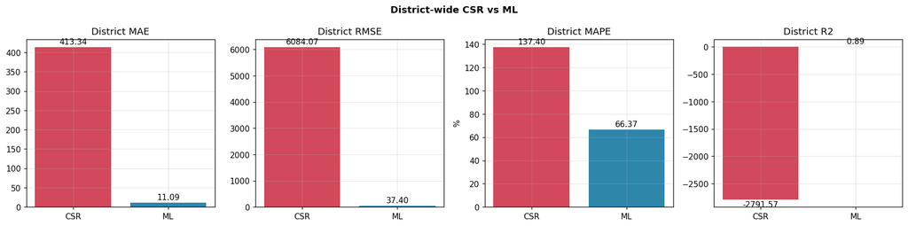

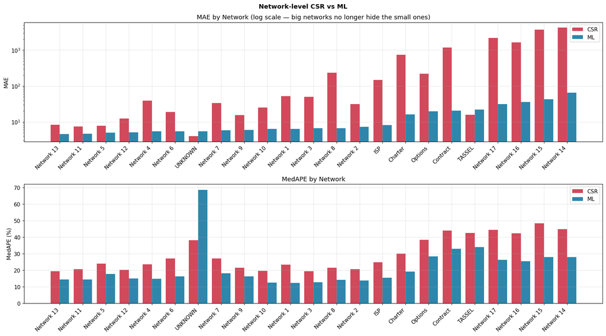

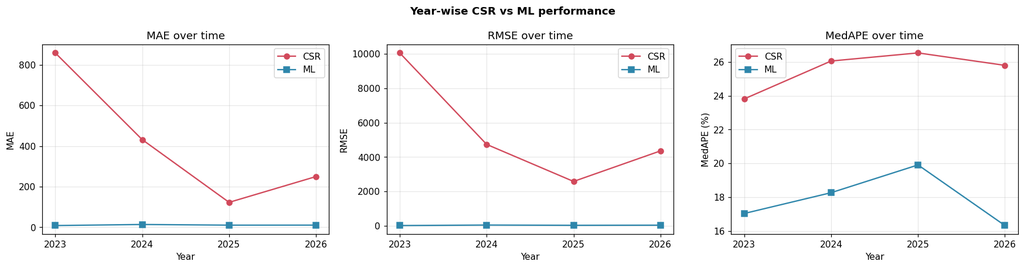

```python
plt.rcParams.update({"figure.dpi": 110, "axes.grid": True, "grid.alpha": 0.3})
CSR_C, ML_C = "#d1495b", "#2e86ab"

# ── 1. District-level grouped bars ────────────────────────────────────────
fig, axes = plt.subplots(1, 4, figsize=(16, 4))
for ax, m in zip(axes, ["MAE", "RMSE", "MAPE", "R2"]):
    vals = [cmp_district.iloc[0][f"{m}_CSR"], cmp_district.iloc[0][f"{m}_ML"]]
    bars = ax.bar(["CSR", "ML"], vals, color=[CSR_C, ML_C])
    ax.set_title(f"District {m}")
    ax.bar_label(bars, fmt="%.2f", padding=2)
axes[2].set_ylabel("%")
fig.suptitle("District-wide CSR vs ML", fontweight="bold")
fig.tight_layout(); plt.show()

# ── 2. Network-level grouped bars (MAE, MedAPE) ───────────────────────────
net = cmp_network.sort_values("MAE_ML")
x = np.arange(len(net)); w = 0.4
fig, axes = plt.subplots(2, 1, figsize=(max(8, len(net) * 0.7), 9))
for ax, m in zip(axes, ["MAE", "MedAPE"]):
    ax.bar(x - w/2, net[f"{m}_CSR"], w, label="CSR", color=CSR_C)
    ax.bar(x + w/2, net[f"{m}_ML"],  w, label="ML",  color=ML_C)
    ax.set_xticks(x); ax.set_xticklabels(net["NETWORK"], rotation=45, ha="right")
    ax.set_ylabel(m + (" (%)" if "APE" in m else ""))
    if m == "MAE":
        ax.set_yscale("log")  # a few high-school networks dwarf the rest on a linear axis
        ax.set_title("MAE by Network (log scale — big networks no longer hide the small ones)")
    else:
        ax.set_title(f"{m} by Network")
    ax.legend()
fig.suptitle("Network-level CSR vs ML", fontweight="bold")
fig.tight_layout(); plt.show()

# ── 3. Year-wise trend lines ──────────────────────────────────────────────
yr = cmp_year.sort_values("YEAR")
fig, axes = plt.subplots(1, 3, figsize=(16, 4.2))
for ax, m in zip(axes, ["MAE", "RMSE", "MedAPE"]):
    ax.plot(yr["YEAR"], yr[f"{m}_CSR"], "o-", color=CSR_C, label="CSR")
    ax.plot(yr["YEAR"], yr[f"{m}_ML"],  "s-", color=ML_C,  label="ML")
    ax.set_title(f"{m} over time"); ax.set_xlabel("Year")
    ax.set_ylabel(m + (" (%)" if "APE" in m else "")); ax.legend()
    ax.set_xticks(yr["YEAR"])
fig.suptitle("Year-wise CSR vs ML performance", fontweight="bold")
fig.tight_layout(); plt.show()
```

## Section 19 — Grade-Wise CSR vs ML Comparison

The same out-of-sample backtest (`preds_pdf`) and `build_comparison()` helper, now grouped by **GRADE**. This shows where the ML model helps most across the grade span — and, for any entry grade present in the data, how each method copes when the feeder signal is weakest. Grades are ordered by `GRADE_ORDER`, not alphabetically.

```python
# ── Grade-wise CSR vs ML error comparison (out-of-sample, all backtest years) ──
cmp_grade = build_comparison(preds_pdf, "GRADE", "GRADE")
cmp_grade["_order"] = cmp_grade["GRADE"].map(lambda g: GRADE_ORDER.get(g, 99))
cmp_grade = cmp_grade.sort_values("_order").drop(columns="_order").reset_index(drop=True)

print("=" * 84)
print("GRADE-WISE  (out-of-sample, all backtest years pooled)")
print("=" * 84)
print(cmp_grade[["GRADE", "n", "MAE_CSR", "MAE_ML", "MAE_impr_%",
                 "RMSE_CSR", "RMSE_ML", "MAPE_CSR", "MAPE_ML",
                 "MedAPE_CSR", "MedAPE_ML", "MAE_winner"]].to_string(index=False))

g_ml_wins = (cmp_grade["MAE_winner"] == "ML").sum()
print(f"\nGrades where ML wins on MAE: {g_ml_wins}/{len(cmp_grade)}")

# Add the grade level to the unified comparison family and persist for the dashboard
unified_grade = tidy(cmp_grade, "Grade", "GRADE")
try:
    spark.createDataFrame(unified_grade.astype({"Group": "string"})) \
        .write.mode("overwrite").option("overwriteSchema", "true") \
        .saveAsTable("csr_vs_ml_comparison_by_grade")
    print("Saved -> 'csr_vs_ml_comparison_by_grade'")
except Exception as e:
    print(f"(Grade comparison table not saved: {e})")
```

```
StatementMeta(, b4c79e94-c416-4b78-8c76-627f086c7518, 26, Finished, Available, Finished, False)
```

```
====================================================================================
GRADE-WISE  (out-of-sample, all backtest years pooled)
====================================================================================
GRADE    n   MAE_CSR  MAE_ML  MAE_impr_%   RMSE_CSR  RMSE_ML  MAPE_CSR  MAPE_ML  MedAPE_CSR  MedAPE_ML MAE_winner
    K 1982   324.096  12.165      96.246  4,682.581   18.986   114.207   38.481      26.022      7.625         ML
    1 1959     7.742   5.753      25.692     15.888    8.910    19.273   20.766      13.224     10.981         ML
    2 1967    32.801   5.206      84.127    591.518   10.787    39.178   22.877      16.078     11.787         ML
    3 1978     8.075   5.282      34.588     27.599    9.169    26.173   25.448      18.429     14.251         ML
    4 2002     8.044   5.169      35.738     43.398    9.534    32.075   36.936      20.184     15.337         ML
    5 2039    46.084   6.090      86.784  1,131.082   13.055    54.246   74.165      23.717     18.490         ML
    6 2031    85.261   7.060      91.720  1,784.412   16.549   143.012   65.058      28.387     19.670         ML
    7 2093   108.052   6.629      93.865  1,337.448   15.986    98.113  107.241      34.403     26.380         ML
    8 2406   962.702  22.819      97.630  7,781.336   81.204   385.851   92.657      49.662     38.504         ML
    9  936 5,747.035  52.857      99.080 25,532.991  107.101   845.989  121.947     120.870     34.643         ML
   10  853   134.986  13.145      90.262  1,491.435   21.486   115.125   66.812      32.246     22.032         ML
   11  880    36.491  10.965      69.952    454.030   20.601    66.536   80.027      29.434     28.268         ML
   12  890    11.088  13.416     -20.995     28.319   24.454    94.793  227.804      44.748     62.399        CSR

Grades where ML wins on MAE: 12/13
Saved -> 'csr_vs_ml_comparison_by_grade'
```

```
StatementMeta(, b4c79e94-c416-4b78-8c76-627f086c7518, 27, Finished, Available, Finished, False)
```

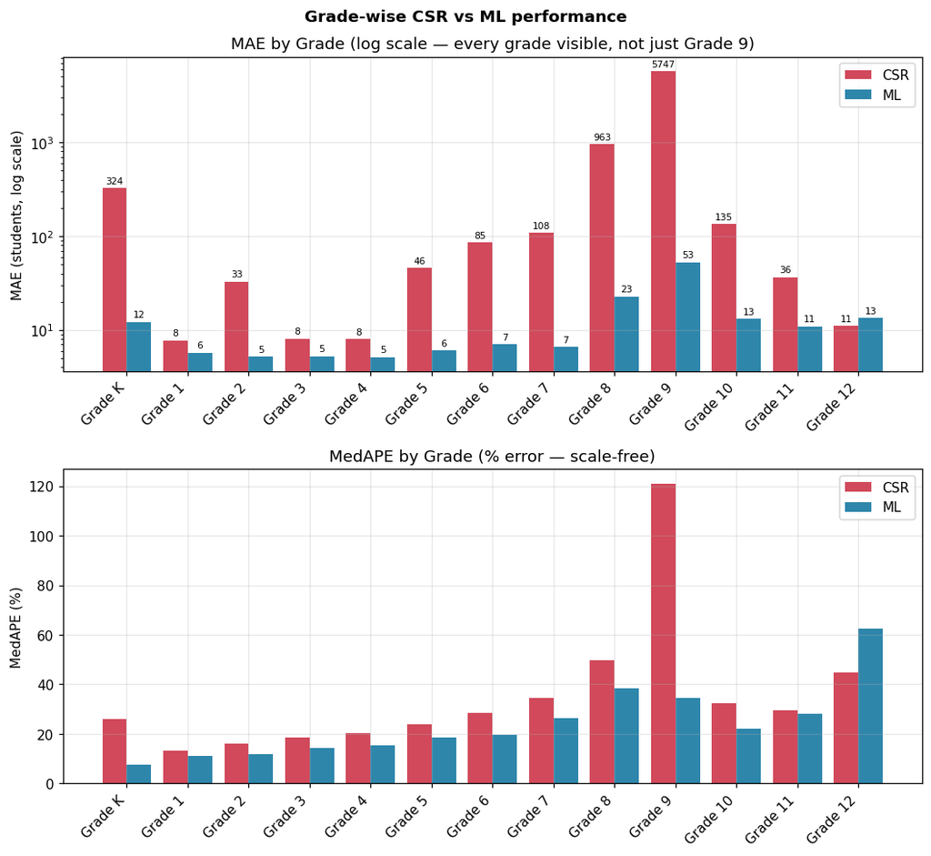

```python
# ── Grade-wise CSR vs ML — MAE on a LOG scale ───────────────────────────────
# Grade 9 (and K) are entry grades with no feeder cohort, so CSR's error there is
# an order of magnitude bigger and crushes every other grade on a linear axis —
# you can only read Grade 9. A log y-axis (plus a value label on every bar) keeps
# it one clean MAE chart while making ALL grades readable. MedAPE (%) below is
# naturally scale-free.
g = cmp_grade.copy()
glab = ["Grade " + str(gr) for gr in g["GRADE"]]
x = np.arange(len(g)); w = 0.4

fig, axes = plt.subplots(2, 1, figsize=(max(9, len(g) * 0.75), 9))

# Row 1 — MAE on a log scale (every grade visible despite Grade 9's spike)
ax = axes[0]
b1 = ax.bar(x - w/2, g["MAE_CSR"], w, label="CSR", color=CSR_C)
b2 = ax.bar(x + w/2, g["MAE_ML"],  w, label="ML",  color=ML_C)
ax.set_yscale("log")
ax.set_xticks(x); ax.set_xticklabels(glab, rotation=45, ha="right")
ax.set_title("MAE by Grade (log scale — every grade visible, not just Grade 9)")
ax.set_ylabel("MAE (students, log scale)")
ax.bar_label(b1, fmt="%.0f", padding=2, fontsize=7)
ax.bar_label(b2, fmt="%.0f", padding=2, fontsize=7)
ax.legend()

# Row 2 — MedAPE (% error — already scale-free, reads fine on a linear axis)
ax = axes[1]
ax.bar(x - w/2, g["MedAPE_CSR"], w, label="CSR", color=CSR_C)
ax.bar(x + w/2, g["MedAPE_ML"],  w, label="ML",  color=ML_C)
ax.set_xticks(x); ax.set_xticklabels(glab, rotation=45, ha="right")
ax.set_title("MedAPE by Grade (% error — scale-free)")
ax.set_ylabel("MedAPE (%)"); ax.legend()

fig.suptitle("Grade-wise CSR vs ML performance", fontweight="bold")
fig.tight_layout(); plt.show()
```

# STAGE 6 — Save Both Models + Forecast

```python
import os
import shutil

# Save the fully trained PipelineModel (with GBTRegressor) as a ZIP file
# Assumes `model` is the trained PipelineModel from Section 11.

# 1. Local temp folder on the driver to save the Spark model
local_model_dir = "/tmp/gbt_enrollment_model"
local_model_uri = f"file:{local_model_dir}"  # Spark expects a URI

# Clean up any previous run
if os.path.exists(local_model_dir):
    shutil.rmtree(local_model_dir)

# 2. Save the full PipelineModel (includes GBTRegressor) locally
model.write().overwrite().save(local_model_uri)
print(f"Model saved to local directory: {local_model_dir}")

# 3. Zip the saved model folder
zip_base = "/tmp/gbt_enrollment_model"          # base path (without .zip)
zip_path = shutil.make_archive(zip_base, "zip", local_model_dir)
print(f"Created ZIP archive at: {zip_path}")

# 4. Copy the ZIP into Lakehouse Files in new directory 'models'
target_dir_in_lakehouse = "Files/models"
notebookutils.fs.mkdirs(target_dir_in_lakehouse)

target_in_lakehouse = f"{target_dir_in_lakehouse}/gbt_enrollment_model.zip"
notebookutils.fs.cp(f"file:{zip_path}", target_in_lakehouse, recurse=False)

print(f"Saved model ZIP to Lakehouse: {target_in_lakehouse}")
```

```
StatementMeta(, b4c79e94-c416-4b78-8c76-627f086c7518, 28, Finished, Available, Finished, False)
```

```
Model saved to local directory: /tmp/gbt_enrollment_model
Created ZIP archive at: /tmp/gbt_enrollment_model.zip
Saved model ZIP to Lakehouse: Files/models/gbt_enrollment_model.zip
```

```python
# ── Save the XGBoost (K & 9) model to the Lakehouse ─────────────────────────
import pickle
local_xgb = "/tmp/xgb_model_k9.pkl"
with open(local_xgb, "wb") as fh:
    pickle.dump(xgb_k9_model, fh)
notebookutils.fs.mkdirs("Files/models")
notebookutils.fs.cp(f"file:{local_xgb}", "Files/models/xgb_model_k9.pkl")
print("Saved XGBoost K/9 model -> Files/models/xgb_model_k9.pkl")
```

```
StatementMeta(, b4c79e94-c416-4b78-8c76-627f086c7518, 29, Finished, Available, Finished, False)
```

```
Saved XGBoost K/9 model -> Files/models/xgb_model_k9.pkl
```

## Section 14 — Forecast Next School Year

Generates enrollment predictions for `FORECAST_END_YEAR` using the trained model. Only **open schools** are included — forecasting closed schools is meaningless.

The latest available row per school-grade is used as the feature template. `SCHOOL_YEAR` is bumped to the forecast year and `IS_MIGRANT_ANOMALY_YEAR` is set to 0 (the anomaly window is treated as over for future forecasts).

```python
# ── Next-year forecast — HYBRID: GBT for grades 1–8/10–12, XGBoost for K & 9 ──
import numpy as np, pandas as pd

forecast_year = FORECAST_END_YEAR
w_latest = Window.partitionBy("SCHOOL_KEY", "GRADE").orderBy(F.col(TIME_COL).desc())

# Most recent actual row per (school, grade) for open schools, rolled to the
# forecast year. Kept RAW here (no median fill yet) so K/9 can go to XGBoost with
# nulls preserved.
latest_raw = (
    df
    .filter(F.col("IS_SCHOOL_OPEN") == 1)
    .withColumn("_rn", F.row_number().over(w_latest))
    .filter(F.col("_rn") == 1).drop("_rn")
    .withColumn(TIME_COL, F.lit(forecast_year))
    .withColumn(WEIGHT_COL, F.lit(1.0))
    .withColumn("IS_MIGRANT_ANOMALY_YEAR", F.lit(0))
)

# 1) GBT scores every grade (median-filled, exactly as it was trained)
gbt_pred = model.transform(latest_raw.fillna(median_fills)).select(
    "SCHOOL_KEY", "GOVERNANCE", "ANNUAL_REGIONAL_ANALYSIS_REGION", "COMMUNITY", "GRADE",
    F.col(TIME_COL).alias("FORECAST_YEAR"),
    F.round("prediction", 0).alias("PREDICTED_ENROLLMENT"),
    "IS_SELECTIVE", "IS_ATTENDANCE_AREA",
)

# 2) XGBoost re-scores K & 9 from the RAW features (nulls kept), then we overwrite
ent = (latest_raw.filter(F.col("GRADE").isin(ENTRY_GRADES))
       .select(*XGB_FEATURES, "GRADE").toPandas())
for c in XGB_FEATURES:
    ent[c] = pd.to_numeric(ent[c], errors="coerce")
ent["GRADE"] = ent["GRADE"].astype(str)
ent["XGB_PRED"] = np.clip(np.round(xgb_k9_model.predict(ent[XGB_FEATURES]), 0), 0, None)

xgb_map = (spark.createDataFrame(ent[["SCHOOL_KEY", "GRADE", "XGB_PRED"]])
           .withColumn("SCHOOL_KEY", F.col("SCHOOL_KEY").cast("long"))
           .withColumn("GRADE", F.col("GRADE").cast("string")))

forecast_out = (
    gbt_pred
    .withColumn("SCHOOL_KEY", F.col("SCHOOL_KEY").cast("long"))
    .withColumn("GRADE", F.col("GRADE").cast("string"))
    .join(xgb_map, on=["SCHOOL_KEY", "GRADE"], how="left")
    .withColumn("PREDICTED_ENROLLMENT",
                F.when(F.col("XGB_PRED").isNotNull(), F.col("XGB_PRED"))
                 .otherwise(F.col("PREDICTED_ENROLLMENT")))
    .drop("XGB_PRED")
    .orderBy("SCHOOL_KEY", "GRADE")
)

n_k9 = ent.shape[0]
print(f"Forecast for SY{forecast_year} (open schools only):")
print(f"  School-grade combinations : {forecast_out.count():,}")
print(f"  Scored by XGBoost (K & 9) : {n_k9:,}  |  rest by GBT")
display(forecast_out.limit(30))

FORECAST_TABLE = f"enrollment_forecast_sy{forecast_year}_{FORECAST_TABLE_SUFFIX}"
forecast_out.write.mode("overwrite").saveAsTable(FORECAST_TABLE)
print(f"\n✔ Hybrid forecast saved to: '{FORECAST_TABLE}'")
```

```
StatementMeta(, b4c79e94-c416-4b78-8c76-627f086c7518, 30, Finished, Available, Finished, False)
```

```
Forecast for SY2027 (open schools only):
  School-grade combinations : 5,911
  Scored by XGBoost (K & 9) : 827  |  rest by GBT
```

```
SynapseWidget(Synapse.DataFrame, 1dba3a53-d91b-4cf0-a4f1-97697ffb1a07)
```

```
✔ Hybrid forecast saved to: 'enrollment_forecast_sy2027_v3_fixed'
```